# BT4212 HW2

```r
# The Quartiles are: 2689 for 25th quartile, 3151 for 50th quartile and 3887 for 75th quartile.

# Compute the standard deviation with na.rm = TRUE
sd_M <- sd(M_distri)
sd_M
```

```
## [1] 693.6817
```

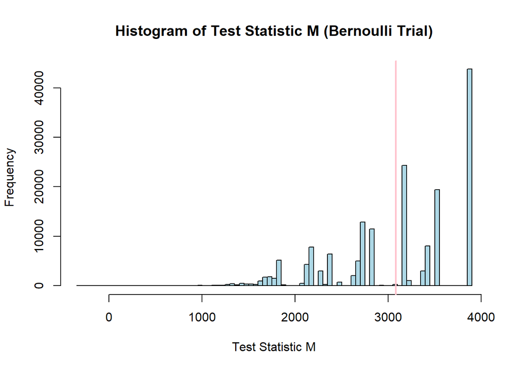

```r
# The Standard Deviation is 693.6817

# Plot histogram for the test statistic M
hist(M_distri, breaks = 100, main = "Histogram of Test Statistic M (Bernoulli Trial)",
     xlab = "Test Statistic M", col = "lightblue", border = "black")
abline(v = mean(M_distri, na.rm = TRUE), col = "pink", lwd = 2)
```

10. Observe when sample size $N$ gets larger, e.g., $N=45$, deriving the exact distribution of the statistic under Fisher Sharp Null Hypothesis becomes time consuming. You could try yourself to see how long it takes to run the code. In this case, we often use “bootstrap” instead, i.e., we will re-execute the randomized assignment procedure for $K$ times. Then, for each iteration, we randomly assign half of the subjects to the control group and the remaining to the treatment group, and we compute the value of our test statistic. Going back to the test statistics $T$. Set $K=100000$. Report (1) the quartiles of the distribution of the test statistic $T$, and (2) the standard deviation. Plot the histogram of this test statistic $T$ with `breaks = 50`. Compare the results with (c) and describe your findings. (5’)

```r
set.seed(1)
N <- 45
K <- 100000

bootstrap_T <- replicate(K, {
  assignment <- sample(c(rep(0, num_of_instances/2), rep(1, num_of_instances/2)))
  mean(result$H0_Y1[assignment == 1]) - mean(result$H0_Y1[assignment == 0])
})

# (1) Calculate quartiles of the test statistic T
quartiles <- quantile(bootstrap_T, c(0.25, 0.50, 0.75), na.rm=TRUE)
quartiles
```

```
##    25%    50%    75%
## -310.2    1.8  313.4
```

```r
# The Quartiles are: -310.2 for 25th quartile, 1.8 for 50th quartile and 313.4 for 75th quartile.

# (2) Calculate the standard deviation of the bootstrap distribution of T
sd(bootstrap_T)
```

```
## [1] 446.4583
```

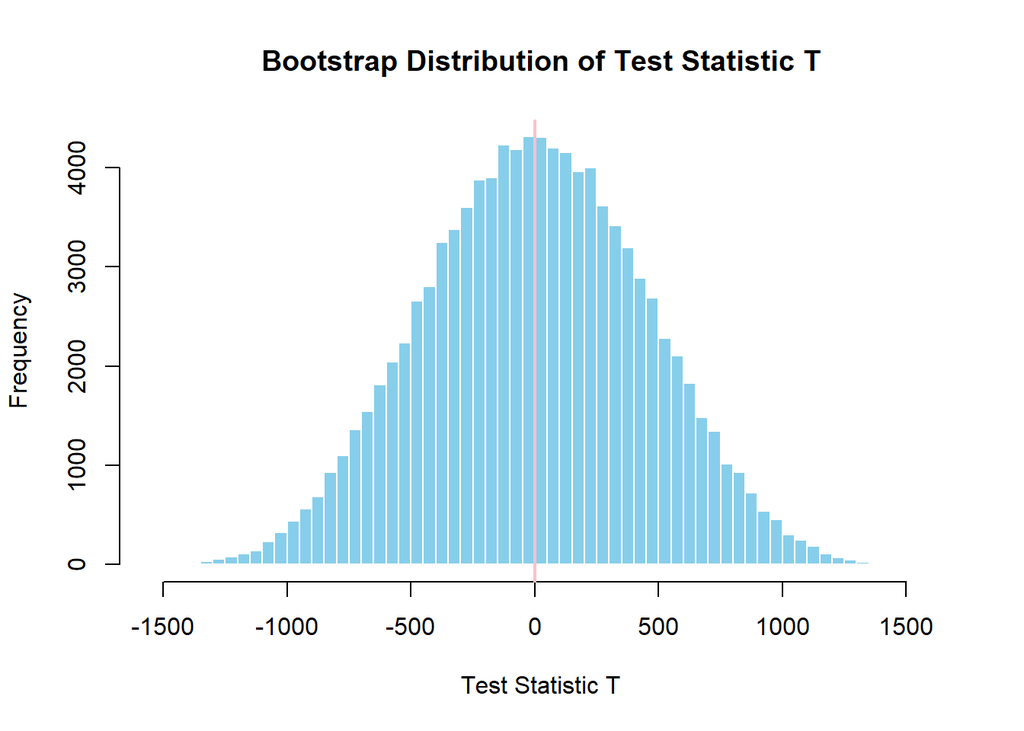

```r
# Standard deviation of the bootstrap distribution is 446.4583

# (3) Plot the histogram of the bootstrap distribution of T with breaks = 50
boostrap_hist <- hist(bootstrap_T, breaks = 50, main = "Bootstrap Distribution of Test Statistic T",
     xlab = "Test Statistic T", col = "skyblue", border = "white")
abline(v = mean(bootstrap_T, na.rm = TRUE), col = "pink", lwd = 2)
```

```r
max(boostrap_hist$counts)
```

```
## [1] 4310
```

```r
# When comparing with c), the quartiles are relatively similar, being [-310.2, 1.8, 313.4] compared to C)'s [-315.050505, -3.131313, 313.030303], along with a similar stadnard deviation of 446.4583, this makes the general spread relatively similar. The mean of 0 for both situations is also present, displaying a similar bell curve shape for both with relatively same spread and mean. Granted there are small deviations, these differences are more likely due to random fluctuations in the sampling process.
# However, the frequency still differs as c) has a maximum frequency of 7198, and the bootstrap method has a smaller maximum frequency of 4310. This is likely due to the exact combinatorial method generating more realizations clustered around the mean value, whereas the bootstrap method relies on repeated random sampling, which leads to a less sharply peaked distribution.
# Overall, the similar quartiles and standard deviation of the bootstrap method compared to the exact combinatorial method shows that it is an effective approximation when exact computation takes a lot of time. However the frequency is less concentrated around the mean due to the bootstrap randomness. This allows it to be a good approximation for large sample sizes.
```